# Reproducible Research: Peer Assessment 1

#### Imputing missing values

1. We calculate the total number of missing values in the dataset (i.e. the total number of rows with NAs)

```r
misVal <- sum(is.na(dataset$steps))
```

The total number missing values is **2304**

2. Devise a strategy for filling in all of the missing values in the dataset.

We use the mean for that 5-minute interval to fill empty variable of steps .

```r
datasetNA<-dataset[is.na(dataset$steps),]
datasetNA[,1] <- sapply(datasetNA[,3],function(x) round(meanStepsPerInterval[meanStepsPerInterval$interval==x,2]))
```

3. Create a new dataset that is equal to the original dataset but with the missing data filled in.

```r
datasetFilled<-dataset
datasetFilled[is.na(dataset$steps),1] <- sapply(dataset[is.na(datasetFilled$steps),3],function(x) round(meanStepsPerInterval[meanStepsPerInterval$interval==x,2]))
```

4. Make a histogram of the total number of steps taken each day and Calculate the mean and median total number of steps taken per day.

[figure not shown]

```r
stepsPerDayF <- aggregate(steps ~ date, data = datasetFilled, FUN = sum, na.rm = TRUE)
hist(stepsPerDay$steps, breaks=30, main="Total number of steps after filling NA", xlab="Steps per day")
```

The mean before filling is **1.0766 × 10<sup>4</sup>** and the median is **1.0765 × 10<sup>4</sup>**

The mean after filling is **1.0766 × 10<sup>4</sup>** and the median is **1.0762 × 10<sup>4</sup>**

There isn’t signicant difference.

#### Are there differences in activity patterns between weekdays and weekends?

1. Create a new factor variable in the dataset with two levels – “weekday” and “weekend” indicating whether a given date is a weekday or weekend day.

```r
datasetFilled$weekday <- as.factor(ifelse(weekdays(datasetFilled$date) %in% c("Saturday","Sunday"), "Weekend", "Weekday"))
```

2. Make a panel plot containing a time series plot (i.e. type = “l”) of the 5-minute interval (x-axis) and the average number of steps taken, averaged across all weekday days or weekend days (y-axis).

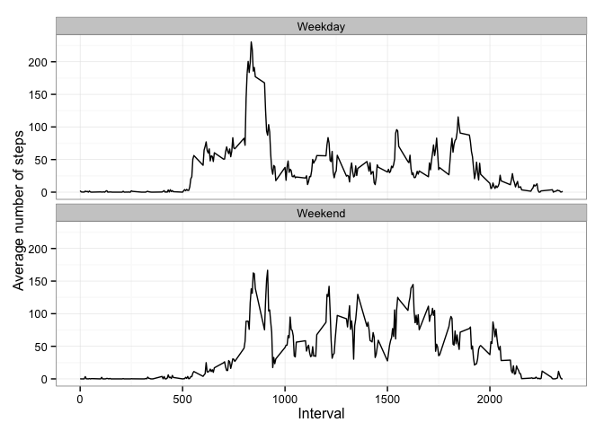

```r
meanStepsWeekDay<-aggregate(datasetFilled$steps,by=list(interval=datasetFilled$interval,weekday=datasetFilled$weekday),FUN=mean)
names(meanStepsWeekDay)[3] <- "steps"

ggplot(meanStepsWeekDay, aes(x=interval, y=steps)) +
    geom_line() +
    facet_wrap(~ weekday, nrow=2, ncol=1) +
    theme_bw()+
    labs(x="Interval", y="Average number of steps")
```